# EEG

Dataset:

Source: Real dataset from Prof. Ding

This starter notebook includes code to extract visualize the EEG recordings from one channel to get you started. You need to check with the instructors or TAs to access this dataset.

```python
import pandas as pd
import matplotlib.pyplot as plt
import numpy as np
```

## 1 Loading data

```python
df = pd.read_csv('../data/eeg_train_subset/C3.csv', header = None)     # returns a DataFrame
# optional: quick peek
df.head()
```

|  | 0 | 1 | 2 | 3 | 4 | 5 | 6 | 7 | 8 | 9 | ... | 28490 | 28491 | 28492 | 28493 | 28494 | 28495 | 28496 | 28497 | 28498 | 28499 |
| --- | --- | --- | --- | --- | --- | --- | --- | --- | --- | --- | --- | --- | --- | --- | --- | --- | --- | --- | --- | --- | --- |
| 0 | -19.069971 | -18.612208 | -20.901025 | -37.685679 | -42.263313 | -19.680322 | -26.394184 | -19.375147 | -23.189841 | -12.050934 | ... | -18.307033 | 15.720040 | 22.433902 | 3.818194 | 27.621887 | 47.000534 | 30.368466 | 28.995177 | -2.437904 | 8.395827 |
| 1 | 19.687322 | 29.605528 | 26.858948 | 34.335749 | 37.082328 | 29.910703 | 44.711717 | 31.741756 | 8.395827 | -18.764796 | ... | -14.644926 | -10.372468 | -1.369790 | -7.778476 | -1.369790 | -1.522378 | -7.015537 | -8.846591 | -11.593171 | -12.508697 |
| 2 | 1.071614 | 15.720040 | 14.804514 | 9.616530 | -8.999179 | 10.226881 | 7.480301 | 12.973461 | 6.869950 | -7.778476 | ... | -3.200843 | -10.372468 | -7.015537 | 4.428545 | 7.022537 | -7.778476 | 8.395827 | 8.090652 | 23.807192 | 9.006179 |
| 3 | 9.006179 | 8.395827 | 26.096009 | 22.586490 | -0.301676 | 23.349429 | 22.281315 | 26.401184 | 0.156088 | 12.973461 | ... | 7.632889 | 9.311354 | -2.590492 | 4.581133 | -0.759439 | 8.090652 | 13.126048 | 4.275958 | 3.207843 | -1.827553 |
| 4 | -1.827553 | -22.732078 | -3.658607 | 4.886309 | 2.139729 | -15.713040 | -4.574133 | 18.161445 | 7.327713 | 21.365788 | ... | -14.797514 | -18.612208 | -3.963782 | -0.759439 | -16.323392 | 9.921705 | 6.107011 | -13.881987 | -46.383182 | 8.090652 |

5 rows × 28500 columns

```python
print(df.shape)
print(df.info())
```

```
(411, 28500)
<class 'pandas.core.frame.DataFrame'>
RangeIndex: 411 entries, 0 to 410
Columns: 28500 entries, 0 to 28499
dtypes: float64(28500)
memory usage: 89.4 MB
None
```

```python
df_label = pd.read_csv('../data/eeg_train_subset/label.csv')     # returns a DataFrame
df_label.head()
```

|  | x |
| --- | --- |
| 0 | 0 |
| 1 | 0 |
| 2 | 0 |
| 3 | 0 |
| 4 | 0 |

```python
print(df_label.shape)
print(df_label.info())
```

```
(411, 1)
<class 'pandas.core.frame.DataFrame'>
RangeIndex: 411 entries, 0 to 410
Data columns (total 1 columns):
 #   Column  Non-Null Count  Dtype
---  ------  --------------  -----
 0   x       411 non-null    int64
dtypes: int64(1)
memory usage: 3.3 KB
None
```

```python
print(df_label['x'].value_counts())
```

```
x
1    213
0    198
Name: count, dtype: int64
```

## 2 Exploratory data analysis

### 2.1 Sample curves and average signals

We can begin by drawing a few sample EEG curves from the healthy patients against the epileptic patients.

```python
random_seed= 42
# Ensure the label column is numeric
labels = pd.to_numeric(df_label['x'], errors='coerce')

# Get indices for healthy (0) and epileptic (1)
hidx = labels[labels == 0].sample(10, random_state=random_seed).index
eidx = labels[labels == 1].sample(10, random_state=random_seed).index
```

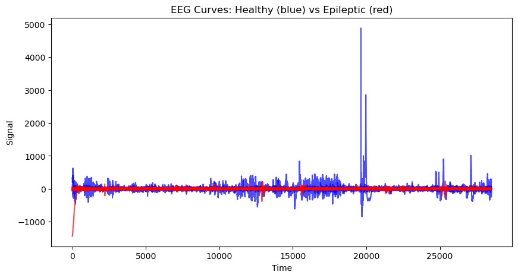

```python
plt.figure(figsize=(10, 5))

# Plot healthy (blue)
for idx in hidx:
    row = df.iloc[idx, :].astype(float).values  # skip first column if it's an index or label
    plt.plot(row, color='blue', alpha=0.7)

# Plot epileptic (red)
for idx in eidx:
    row = df.iloc[idx, :].astype(float).values
    plt.plot(row, color='red', alpha=0.7)

plt.xlabel('Time')
plt.ylabel('Signal')
plt.title('EEG Curves: Healthy (blue) vs Epileptic (red)')
plt.show()
```

It is clear that there are extreme values in the EEG signals that makes the plot hard to read. We can try moving window smoothing + zooming in certain range of signals for better visualization.

```python
D = 100  # window size for smoothing

def moving_average(arr, window):
    return np.convolve(arr, np.ones(window)/window, mode='valid')

# Smooth healthy samples
smoothed_healthy = []
for idx in hidx:
    row = df.iloc[idx, :].astype(float).values
    smoothed_healthy.append(moving_average(row, D))

# Smooth epileptic samples
smoothed_epileptic = []
for idx in eidx:
    row = df.iloc[idx, :].astype(float).values
    smoothed_epileptic.append(moving_average(row, D))
```

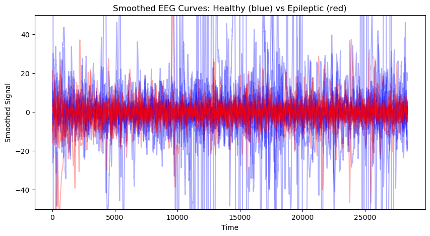

```python
plt.figure(figsize=(10, 5))

# Plot smoothed healthy (blue)
for arr in smoothed_healthy:
    plt.plot(arr, color='blue', alpha=0.3)

# Plot smoothed epileptic (red)
for arr in smoothed_epileptic:
    plt.plot(arr, color='red', alpha=0.3)

plt.title('Smoothed EEG Curves: Healthy (blue) vs Epileptic (red)')
plt.xlabel('Time')
plt.ylabel('Smoothed Signal')
plt.ylim(-50, 50)
plt.show()
```

We can already see some interesting differences between the red curves and blue curves. Let's see if we can find more differences on the grand average.

```python
# Get indices of epileptic patients (label == 1)
epileptic_indices = labels[labels == 1].index

# Obtain the rows in df using these indices
epileptic_rows = df.iloc[epileptic_indices, :].astype(float)

# Take the average across rows (axis=0)
eeg_epileptic = epileptic_rows.mean(axis=0).values
```

```python
# Get indices of epileptic patients (label == 1)
healthy_indices = labels[labels == 0].index

# Obtain the rows in df using these indices
healthy_rows = df.iloc[healthy_indices, :].astype(float)

# Take the average across rows (axis=0)
eeg_healthy = healthy_rows.mean(axis=0).values
```

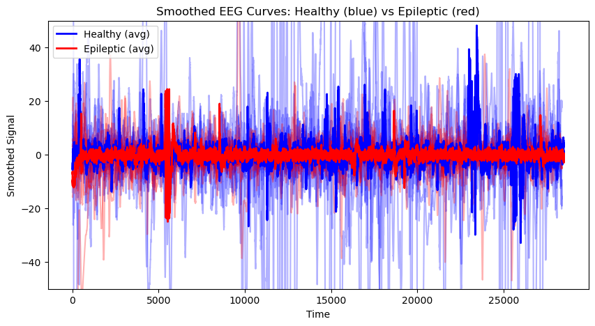

```python
plt.figure(figsize=(10, 5))

# Plot smoothed healthy (blue)
for arr in smoothed_healthy:
    plt.plot(arr, color='blue', alpha=0.3)

# Plot smoothed epileptic (red)
for arr in smoothed_epileptic:
    plt.plot(arr, color='red', alpha=0.3)

# Add grand average curves
plt.plot(eeg_healthy, color='blue', linewidth=2, label='Healthy (avg)')
plt.plot(eeg_epileptic, color='red', linewidth=2, label='Epileptic (avg)')

plt.title('Smoothed EEG Curves: Healthy (blue) vs Epileptic (red)')
plt.xlabel('Time')
plt.ylabel('Smoothed Signal')
plt.ylim(-50, 50)
plt.legend()
plt.show()
```

### 2.2 Variance curves

It appears that the healthy EEG signals show stronger variability than the epileptic signals. We can try to calculate the variances using a moving window approach.

```python
# Calculate moving window variance for each row in df
window_size = D  # D is already defined above

def moving_variance(arr, window):
    return pd.Series(arr).rolling(window=window).var().dropna().values

# Create a new DataFrame to store the moving variances
moving_var_df = pd.DataFrame(
    [moving_variance(df.iloc[i, :].astype(float).values, window_size) for i in range(df.shape[0])]
)
moving_sd_df = np.sqrt(moving_var_df)
```

```python
moving_sd_df = np.sqrt(moving_var_df)
```

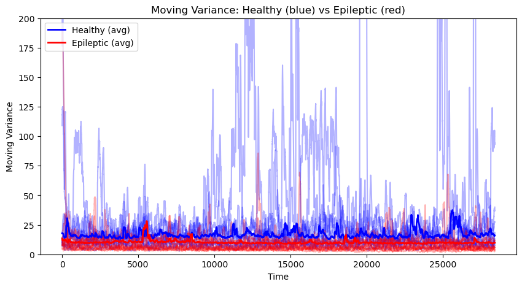

```python
random_seed = 42
# Ensure the label column is numeric
labels = pd.to_numeric(df_label['x'], errors='coerce')

# Get indices for healthy (0) and epileptic (1)
hidx = labels[labels == 0].sample(10, random_state=random_seed).index
eidx = labels[labels == 1].sample(10, random_state=random_seed).index

# Get indices of epileptic patients (label == 1)
epileptic_indices = labels[labels == 1].index

# Obtain the rows in moving_var_df using these indices
epileptic_rows = moving_sd_df.iloc[epileptic_indices, :].astype(float)

# Take the average across rows (axis=0)
eeg_epileptic = epileptic_rows.mean(axis=0).values

# Get indices of healthy patients (label == 0)
healthy_indices = labels[labels == 0].index

# Obtain the rows in moving_var_df using these indices
healthy_rows = moving_sd_df.iloc[healthy_indices, :].astype(float)

# Take the average across rows (axis=0)
eeg_healthy = healthy_rows.mean(axis=0).values

plt.figure(figsize=(10, 5))

# Plot healthy (blue)
for idx in hidx:
    row = moving_sd_df.iloc[idx, :].astype(float).values
    plt.plot(row, color='blue', alpha=0.3)

# Plot epileptic (red)
for idx in eidx:
    row = moving_sd_df.iloc[idx, :].astype(float).values
    plt.plot(row, color='red', alpha=0.3)

# Add grand average curves
plt.plot(eeg_healthy, color='blue', linewidth=2, label='Healthy (avg)')
plt.plot(eeg_epileptic, color='red', linewidth=2, label='Epileptic (avg)')

plt.title('Moving Variance: Healthy (blue) vs Epileptic (red)')
plt.xlabel('Time')
plt.ylabel('Moving Variance')
plt.ylim(0, 200)
plt.legend()
plt.show()
```

## 3 Next step?